# 06-order-statistics

Shuyang Lin

10/21/2021

# Which quantiles of a continuous distribution can one estimate with more precision?

The median is an important quantity in data analysis. It represents the middle value of the data distribution. Estimates of the median, however, have a degree of uncertainty because (a) the estimates are calculated from a finite sample and (b) the data distribution of the underlying data is generally unknown. One important roles of a data scientist is to quantify and to communicate the degree of uncertainty in his or her data analysis.

# Background Knowledge

The $k^{th}$ **Order statistic** is equal to the $k^{th}$ smallest value of a statistical sample.[^1] When the values of the random variable $X$ is marked as $X_1$, $X_2$, …, $X_n$, the corresponding order statistics are marked as $X_{(1)}$, $X_{(2)}$, …, $X_{(n)}$.

Given a sample of absolutely continuous random variable $X$, $P(X_{(k)}\leq x < X_{(k+1)})$ is equivalent to the probability that $k$ samples less than or equal to $x$, and $n-k$ samples greater than $x$. Therefore, it’s similar to the binomial distribution, and the probability could be given as below:

$$P(X_{(k)}\leq x < X_{(k+1)})=C_n^k[F(x)]^k[1-F(x)]^{n-k}$$
Then, since each $X_k$ is independent and identically distributed, the event $\{X_{(k)}\leq x\}$ is equivalent to $\bigcup\limits_{i=k}^n\{X_{(i)}\leq x\}$ because each $\{X_{(k)}\leq x < X_{(k+1)}\}$ is exclusive.

Therefore, the CDF of the order statistic is given as below:

$$F_{X_{(k)}}(x) =\sum_{i=k}^nC_n^i[F(x)]^i[1-F(x)]^{n-i}$$

The PDF could be derived from the CDF above.

# Solutions to Questions

- **Q1: Begin with the median from a sample of N = 200 from the standard normal distribution. Write an R function that is the density function for the median in this sample. Note that the 100th order statistic is approximately the median, and use the order statistic formula discussed in class. Generate a plot of the function.**

The function could be given by the PDF of the order statistics:

$$f_{X_{(k)}}(x) = kC_n^k f_X(x)[F_X(x)]^{k-1}[1-F_X(x)]^{n-k}$$

Where $k=100$, $n=200$, $f_X(x)$ is the PDF of the standard normal distribution and $F_X(x)$ is the CDF.

```r
dorder <- function(x){
  100*choose(200, 100)*pnorm(x)^99*(1-pnorm(x))^100*dnorm(x)
}
```

And we draw the plot of it:

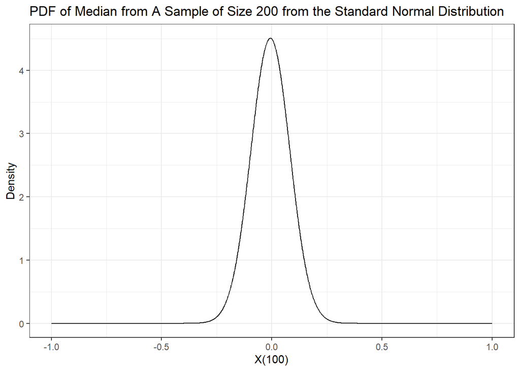

```r
sample <- data.frame(seq(-1,1,0.001))
colnames(sample) <- c('median')
sample$dorder <- dorder(sample$median)
(
  dorder_plot <- ggplot(sample, aes(x=median, y=dorder)) + geom_line() + theme_bw() +
                labs(
                  title = 'PDF of Median from A Sample of Size 200 from the Standard Normal Distribution',
                  x = 'X(100)',
                  y = 'Density'
                )
)
```

From the plot, we can see that the distribution of the sample’s median is symmetrical around 0. That is reasonable and apparent because the median of the population is 0. Although the sample’s median is random, it still should stick to 0 and follow a distribution similar to the normal distribution. In fact, I didn’t learn anything new from this plot.

- **Q2: Write an R function that is the probability function for the median in this sample. Use the order statistic formula discussed in class. Generate a plot of the function.**

The CDF is also given by the PDF of the order statistics:

$$F_{X_{(r)}}(x) = \sum_{i=k}^{n}C_n^k[F_X(x)]^i[1-F_X(x)]^{n-i}$$

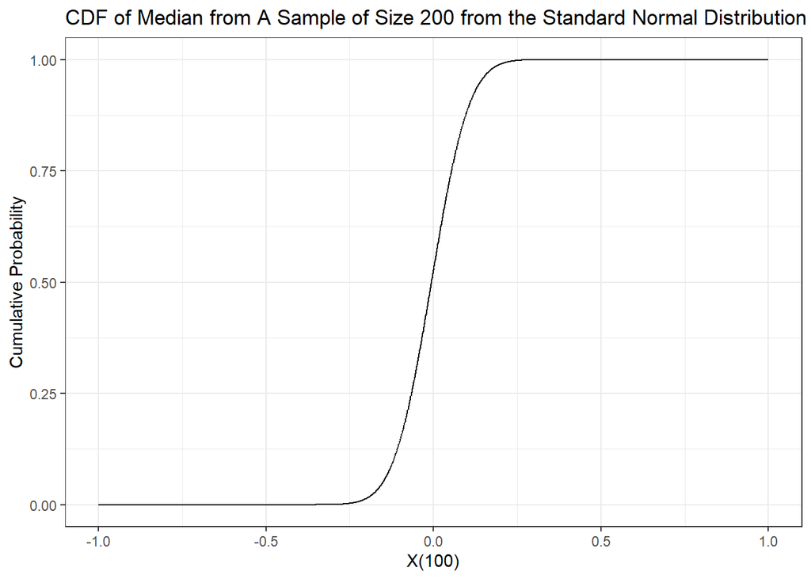

```r
porder <- function(x){
  1 - pbinom(99, 200, pnorm(x))
}

# draw the plot
sample$porder <- porder(sample$median)
(
  porder_plot <- ggplot() + geom_line(sample, mapping = aes(x=median, y=porder)) + theme_bw() +
                labs(
                  title = 'CDF of Median from A Sample of Size 200 from the Standard Normal Distribution',
                  x = 'X(100)',
                  y = 'Cumulative Probability'
                )
)
```

The CDF plot shows nearly nothing new compared to the PDF. It shows the distribution of the 100th order statistic, which is the sample’s median.

- **Q3: Write an R function that is the quantile function for the median in this sample. (You have several options for how to write this function.) Generate a plot of the function.**

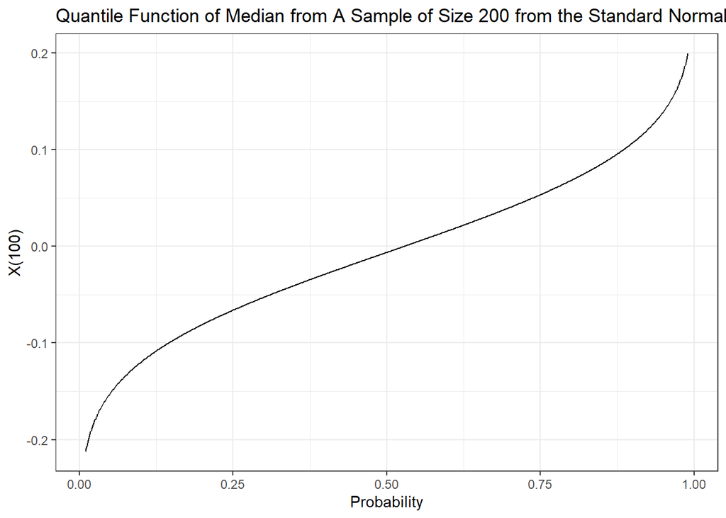

```r
qorder <- function(p){
  uniroot(function(x){porder(x) - p}, c(-100, 100))$root
}

# draw the plot
qsample <- data.frame(seq(0.01,0.99,0.001))
colnames(qsample) <- c('q')
qsample$median <- sapply(qsample$q, qorder)
(
  qorder_plot <- ggplot() + geom_line(qsample, mapping = aes(x=q,y=median)) + theme_bw() +
                labs(
                  title = 'Quantile Function of Median from A Sample of Size 200 from the Standard Normal Distribution',
                  x = 'Probability',
                  y = 'X(100)'
                )
)
```

The function qorder() is the reverse function of porder(). If we do an axisymmetric with the bottom left to top right diagonal, the plot will become a cut of the plot of the CDF with X(100) in an interval around [-0.22, 0.22].

- **Q4: Simulate the sampling distribution for the median. Create a plot of the empirical CDF (ECDF). Overlay the plot of the ECDF with a plot of the CDF.**

We first generate 10,000 samples of size 200, and record their median, then we draw the plot using stat_ecdf() function in ggplot2:

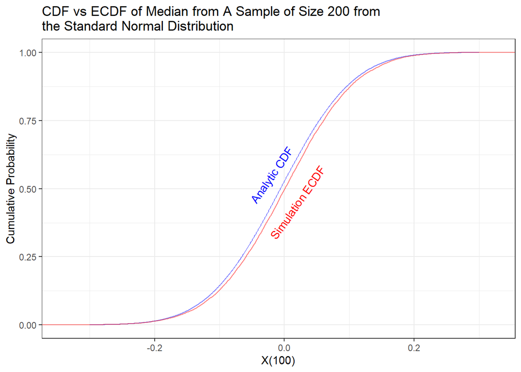

```r
set.seed(1)
medsample <- sapply(lapply(matrix(200,10000,1), rnorm),median)

# draw the plot
(
  medsample_plot <- ggplot() +
    geom_line(aes(x=seq(-0.3, 0.3, 0.001), y=porder(seq(-0.3, 0.3, 0.001))), alpha = 0.5, color = 'blue') + geom_text(aes(x=-0.02, y = 0.55), angle = 55, label = 'Analytic CDF',color = 'blue')+
    theme_bw() +
    stat_ecdf(aes(x=medsample), color = 'red', alpha = 0.5) +
    geom_text(aes(x=0.02, y = 0.45), angle= 55,label = 'Simulation ECDF', color = 'red')+
    labs(
      title = 'CDF vs ECDF of Median from A Sample of Size 200 from\nthe Standard Normal Distribution',
      x = 'X(100)',
      y = 'Cumulative Probability'
    ) +
    scale_x_continuous()
)
```

We may see that the analytic CDF and the simulation ECDF share the same trend. However, they are not exactly equal to the other. That is the inevitable deviation of simulations.

- **Q5: Using the simulated sampling distribution from the previous question, create a histogram (on the density scale). Overlay the histogram with a plot of the density function.**

The plot is given by the code below:

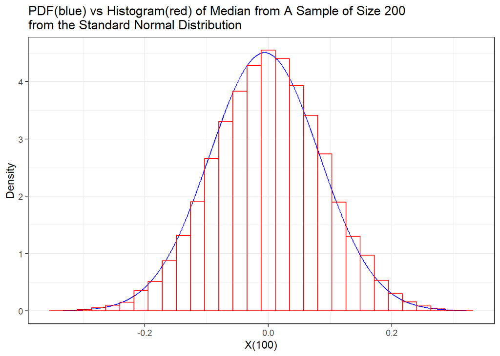

```r
(
  medsample_plot2 <- ggplot() +
                geom_line(
                  aes(
                    x=seq(min(medsample),max(medsample),0.001),
                    y = dorder(seq(min(medsample),max(medsample),0.001))
                  ),
                  color='blue'
                )+
                geom_histogram(
                  aes(x=medsample, y =..density..),
                  color = 'red', fill=NA, bins = 30
                )+
                theme_bw() +
                labs(
                  title = 'PDF(blue) vs Histogram(red) of Median from A Sample of Size 200\nfrom the Standard Normal Distribution',
                  x = 'X(100)',
                  y = 'Density'
                )
)
```

The histogram is shown in density format. We could see that the simulation solution shares a similar trend with the analytic solution. However, since the histogram is built in left tail way, we could see that the density is not axisymmetric.

- **Q6: One very common way to compare a random sample to a theoretical candidate distribution is the QQ plot. It is created by ploting quantiles of the theoretical distribution on the x-axis and empirical quantiles from the sample on the y-axis.**

**If sample and theoretical quantiles come from the same distribution, then the plotted points will fall along the line y = x, approximately. Here are two examples when the sample and theoretical quantiles came from the same distribution.**

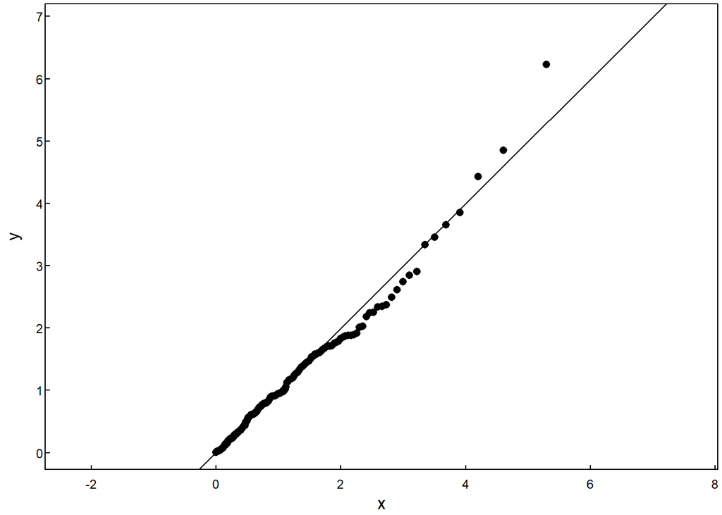

```r
random_sample <- rexp(200)
q_candidate <- qexp

x <- q_candidate((1:200)/200)
y <- quantile(random_sample, probs = (1:200)/200)

tgsify::plotstyle(style = upright)
plot(x,y, asp = 1)
abline(0,1)
```

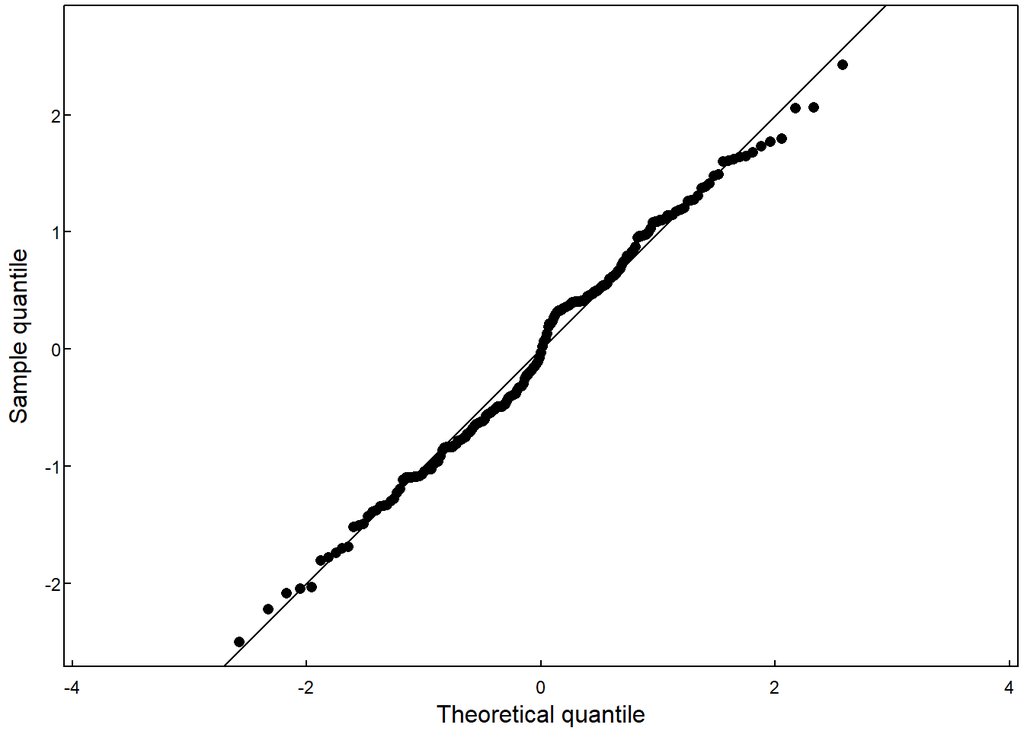

```r
random_sample <- rnorm(200)
q_candidate <- qnorm

x <- q_candidate((1:200)/200)
y <- quantile(random_sample, probs = (1:200)/200)

tgsify::plotstyle(style = upright)
plot(x,y, asp = 1, xlab = "Theoretical quantile", ylab = "Sample quantile")
abline(0,1)
```

**Here is an example when the sample distribution does not match with the theoretical distribution. The sample distribution is t3 where as the theoretical distribution is N(0, 1). Notice the deviation from y = x.**

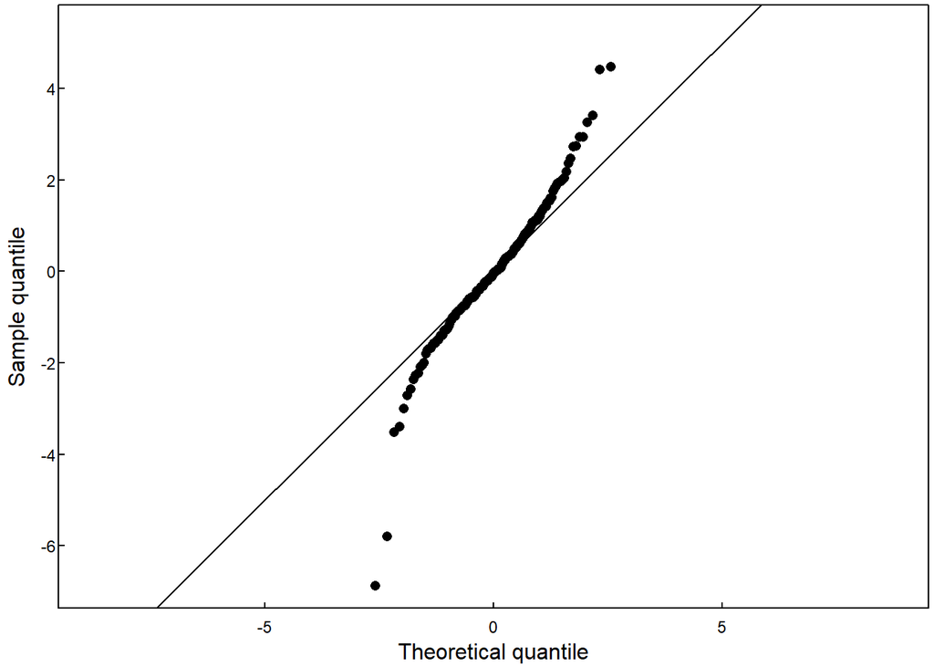

```r
random_sample <- rt(200, df = 3)
q_candidate <- qnorm

x <- q_candidate((1:200)/200)
y <- quantile(random_sample, probs = (1:200)/200)

tgsify::plotstyle(style = upright)
plot(x,y, asp = 1, xlab = "Theoretical quantile", ylab = "Sample quantile")
abline(0,1)
```

**The deviation occurs despite the fact that the two distributions are similar.For the assignment, generate a QQ plot for the simulated data of the median relative to the known sampling distribution of the median.Does the simulated data agree with the theoretical sampling distribution?**

Lets draw the qqplot first. The vector **qsample**, which is the theoretical quantiles, are given by the qorder() function in the solution to Q3:

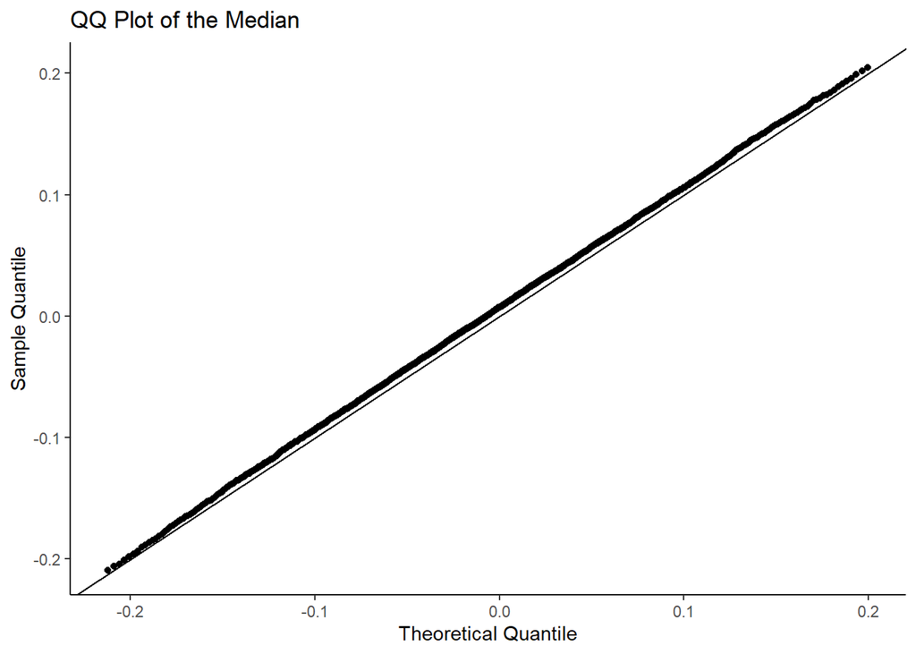

```r
sampleq <- sapply(seq(0.01, 0.99, 0.001), quantile, x=medsample)
(
  qqplot <- ggplot() +
              geom_point(aes(x=qsample$median, y=sampleq)) +
              labs(
                title='QQ Plot of the Median',
                x='Theoretical Quantile',
                y='Sample Quantile'
              ) +
              geom_abline(slope=1,intercept=0)+
              theme_classic()
)
```

We could see though they are nearly the same, the points are nearly lying on the line $y=x$, which indicates that they are not exactly equal, but the simulated data does agree with the theoretical sampling distribution, sharing a similar distribution.

- **Q7: Modify the dorder, porder, and qorder functions so that the functions take a new parameter k (for the** $k^{t^h}$ **order statistic) so that the functions will work for any order statistic and not just the median.**

The functions are given below, replacing 100 with k, 200-100 with 200-k, and 99 with k-1:

```r
dorder <- function(x, k){
  k*choose(200, k)*pnorm(x)^(k-1)*(1-pnorm(x))^(200-k)*dnorm(x)
}

porder <- function(x, k){
  1 - pbinom(k-1, 200, pnorm(x))
}

qorder <- function(p, k){
  uniroot(function(x){porder(x, k) - p}, c(-100, 100))$root
}
```

- **Q8: Generate the QQ plot for simulated data from the sampling distribution of the sample max and the theoretical largest order statistic distribution.**

The sample max is given as below:

```r
maxsample <- sapply(lapply(matrix(200,10000,1), rnorm),max)
```

Then we use qorder() to generate the theoretical largest order statistic, calculate the quantiles, and draw a QQ plot:

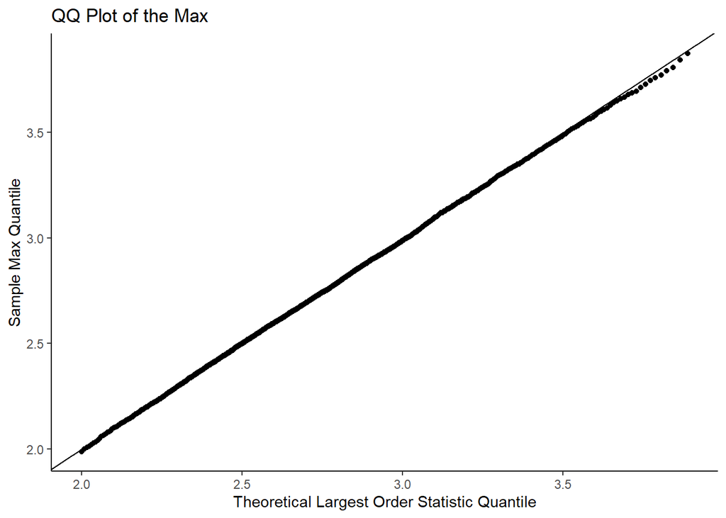

```r
(
  qqplot_max <- ggplot() +
              geom_point(
                aes(
                  x=sapply(seq(0.01,0.99,0.001), qorder, k=200),
                  y=quantile(maxsample, probs=seq(0.01,0.99,0.001))
                )
              ) +
              labs(
                title='QQ Plot of the Max',
                x='Theoretical Largest Order Statistic Quantile',
                y='Sample Max Quantile'
              ) +
              geom_abline(slope=1,intercept=0)+
              theme_classic()
)
```

They are nearly the same, which means with a large size, sampling is good to straightly get an estimated value in most cases if a slight deviation is allowed.

- **Q9: Modify the dorder, porder, and qorder functions so that the functions take new parameters dist and … so that the functions will work for any continuous distribution that has d and p functions defined in R.**

The functions are modified as below:

```r
dorder <- function(x, k, dist='norm'){
  f <- eval(parse(text=paste0("d",dist)))
  F <- eval(parse(text=paste0("p",dist)))
  k*choose(200, k)*F(x)^(k-1)*(1-F(x))^(200-k)*f(x)
}

porder <- function(x, k, dist='norm'){
  1 - pbinom(k-1, 200, eval(parse(text=paste0("p",dist)))(x))
}

qorder <- function(p, k, dist='norm'){
  uniroot(function(x){porder(x, k, dist) - p}, c(-100, 100))$root
}
```

- **Q10: Use the newly modified functions to plot the probability and density functions for the sample min (N = 200).**

We need to use dorder() for density:

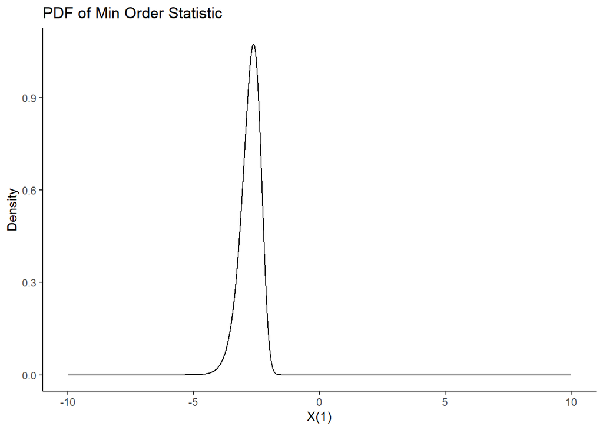

```r
# density
(
  density_min <- ggplot() +
                  geom_line(
                    aes(
                      x=seq(-10,10,0.001),
                      y = dorder(seq(-10,10,0.001),1)
                    )
                  ) +
                  labs(
                    title='PDF of Min Order Statistic',
                    x='X(1)',
                    y='Density'
                  ) +
                  theme_classic()
)
```

…And porder() for probability

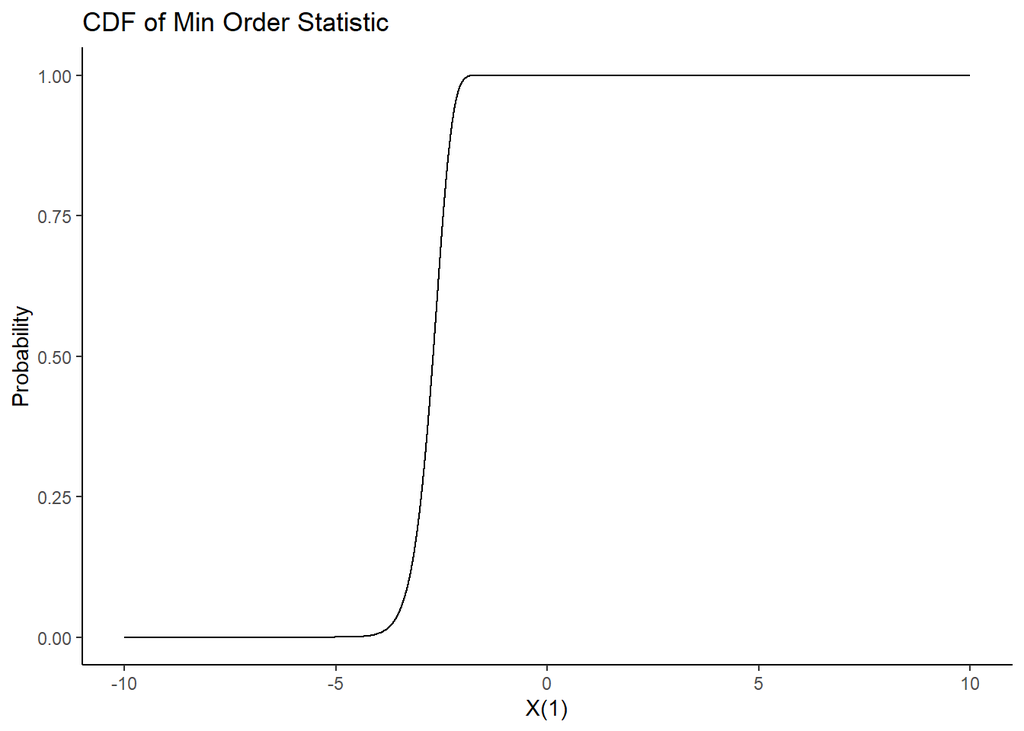

```r
# probability
(
  probability_min <- ggplot() +
                      geom_line(
                        aes(
                          x=seq(-10,10,0.001),
                          y=porder(seq(-10,10,.001),1)
                        )
                      ) +
                      labs(
                        title='CDF of Min Order Statistic',
                        x='X(1)',
                        y='Probability'
                      ) +
                      theme_classic()
)
```

From the PDF’s plot, we could see that the sample’s X(1) distribution is not axisymmetric. That is fair because the population follows a standard normal distribution, which holds the value of the random variable being too far away from the mean. Therefore, since we have an expectation of X(1), X(1) is more likely to be larger than that expectation, compared to be smaller than. The CDF, shows a vague interval of the X(1) could be in.

# Reference Links

[^1]: [Order statistic - Wikipedia](https://en.wikipedia.org/wiki/Order_statistic)